# HW 7

Data 180, Professor Kennedy

Peter Guma

gumap@dickinson.edu

December 04, 2023

**Due date:** December 4 beginning of class.

In this homework, we will analyze news headlines data scraped from abcnews, posted on Github in a csv file named `news.csv`.

Read the `news.csv` into R and create the object `news` using

```r
library(tidyverse)
library(dplyr) # I added this so it would knit properly
library(tm)
setwd("C:/Users/Peter/Documents/College Documents/DATA 180/Data 180 Peter Guma/DATA-180-PETER-GUMA/hw7")
news<-read.csv("news.csv",header=T)
```

Read also the positive and negative word dictionaries, both found on Github. This will later come in handy:

```r
posWords <- scan("positive-words.txt", character(0), sep = "\n")  # 2006 items
negWords <- scan("negative-words.txt", character(0), sep = "\n")  # 4783 items
head(posWords,15)
```

```
##  [1] "a+"            "abound"        "abounds"       "abundance"
##  [5] "abundant"      "accessable"    "accessible"    "acclaim"
##  [9] "acclaimed"     "acclamation"   "accolade"      "accolades"
## [13] "accommodative" "accomodative"  "accomplish"
```

```r
head(negWords,15)
```

```
##  [1] "2-faced"     "2-faces"     "abnormal"    "abolish"     "abominable"
##  [6] "abominably"  "abominate"   "abomination" "abort"       "aborted"
## [11] "aborts"      "abrade"      "abrasive"    "abrupt"      "abruptly"
```

# Question 1

First, check how many years of news data we have loaded in in R.

```r
nrow(news)
```

```
## [1] 10000
```

# Question 2

Store the headlines column in a vector of text named `charVector`. Print the first 6 entries in the vector.

```r
charVector <- news$headline_text
head(charVector)
```

```
## [1] "people flock to kabul airport as taliban seizes capital"
## [2] "senior liberals desert turnbull"
## [3] "interview matt scott"
## [4] "one plus one: jim cassidy"
## [5] "more australians leave lebanon"
## [6] "melb housing plan released"
```

# Question 3

Convert `charVector` into a vector source object named `wordVector` using the function `VectorSource()`. (See class notes on how to do this) Then convert `wordVector` into a corpus object named `wordCorpus` using the function `Corpus()`.

```r
wordVector <- VectorSource(charVector)
wordCorpus <- Corpus(wordVector)
```

# Question 4

```r
wordCorpus <- tm_map(wordCorpus, tolower)
wordCorpus <- tm_map(wordCorpus, removePunctuation)
wordCorpus <- tm_map(wordCorpus, removeNumbers)
wordCorpus <- tm_map(wordCorpus, removeWords, stopwords("en"))
```

# Question 5

What is a term document matrix? Explain. Create a term document matrix from the news vector and store it as an object named `tdm` using the function `TermDocumentMatrix`.

```r
tdm <- TermDocumentMatrix(wordCorpus)
```

# Question 6

Convert `tdm` into a matrix named `m`. Store the frequency of occurrence of each word in the news headlines in an object named `wordCounts`. Return the top 10 most frequent words. (Note: if you run into memory issues creating the matrix `m`, try using one of the computers in Tome.)

```r
m <- as.matrix(tdm)
wordCounts <- rowSums(m)
sortedWordCounts <- sort(wordCounts, decreasing = TRUE)
head(sortedWordCounts, n=10)
```

```
##     police        man        new       says      court  australia    council
##        338        251        241        176        159        141        138
##       fire australian       govt
##        132        126        123
```

# Question 7

Create a barplot of the words that showed up at least 50 times in the news headlines. Rotate the x axis labels by 90 degrees, and decrease the label font size by 25%.

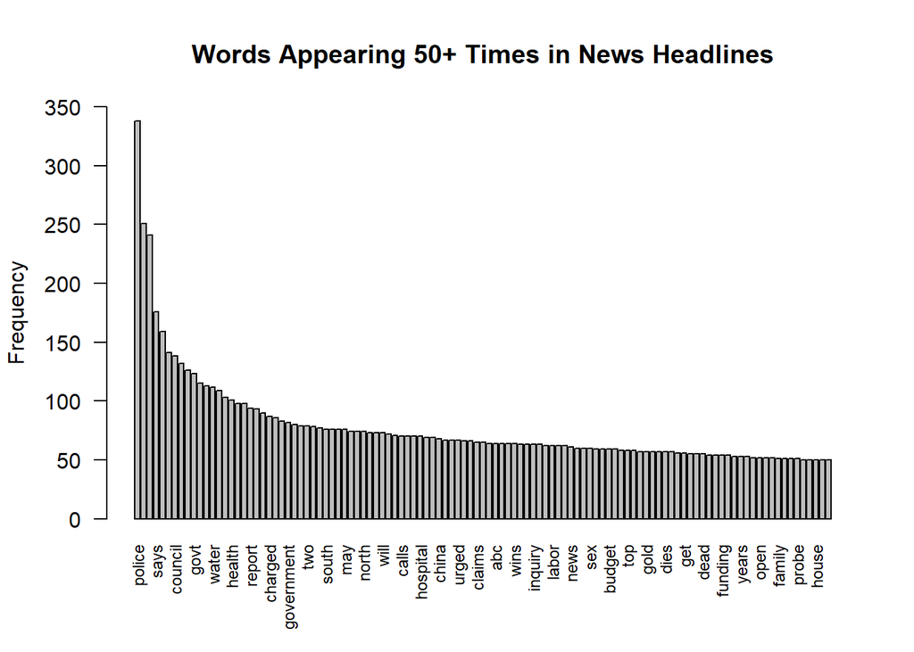

```r
barplot(sortedWordCounts[sortedWordCounts>=50], ylab="Frequency", las=2, cex.names=.75, ylim=c(0,350), main="Words Appearing 50+ Times in News Headlines")
```

```r
# ggplot(wordCounts, aes()) + geom_bar()
```

# Question 8

What is the percentage of positive words in the news headlines? What is the percentage of negative words? Make a barplot for each (for positive and negative words that showed up separately) showing the most frequent words for words that showed up at least 20 times. (Note: don’t forget to get the total number of unique words that showed up in the data.)

```r
totalUnique = nrow(unique(m))
num_pos <- 0
num_neg <- 0

# for (i in posWords) {
#  if (posWords[i] %in% unique(m)) {
#      num_pos <- num_pos+1 }
#}

pos_match <- match(names(wordCounts), posWords, nomatch = 0)
pos_match <- pos_match != 0
pos_match <- wordCounts[pos_match]
pos_match
```

[output not shown]

[output cut: 103 more lines]

[output not shown]

```r
neg_match <- match(names(wordCounts), negWords, nomatch = 0)
neg_match <- neg_match != 0
neg_match <- wordCounts[neg_match]
neg_match
```

[output not shown]

[output cut: 289 more lines]

[output not shown]

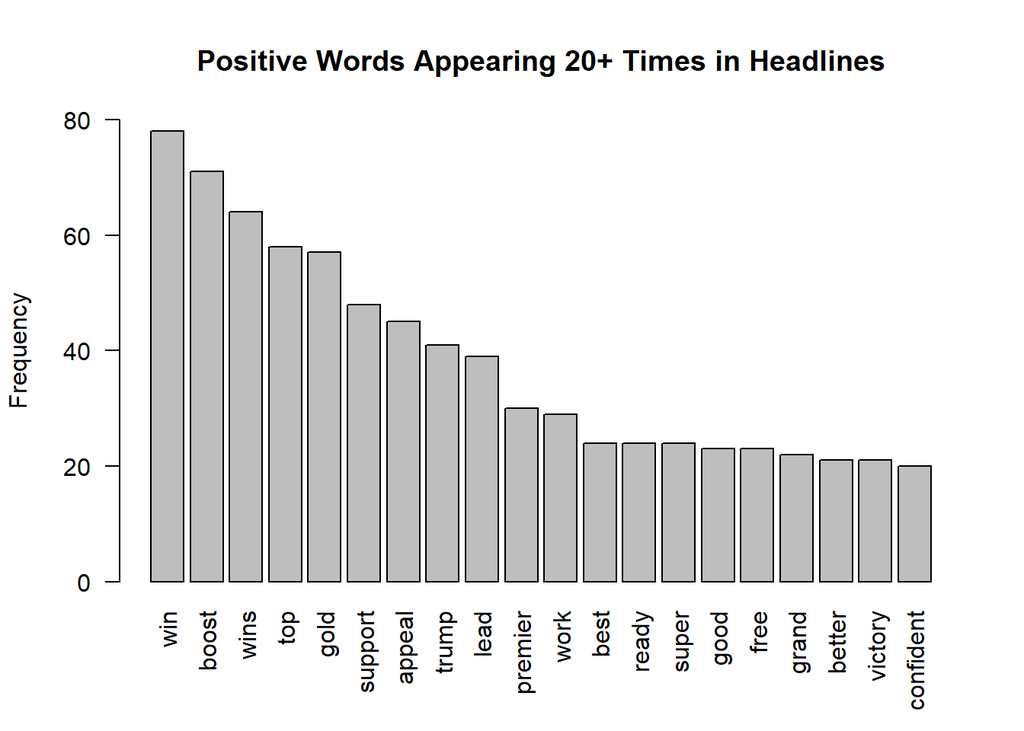

```r
pct_pos <- sum(pos_match)/totalUnique
pct_neg <- sum(neg_match)/totalUnique

barplot(sort(pos_match[pos_match>=20], decreasing=TRUE), ylab="Frequency", las=2, ylim=c(0,80), main="Positive Words Appearing 20+ Times in Headlines")
```

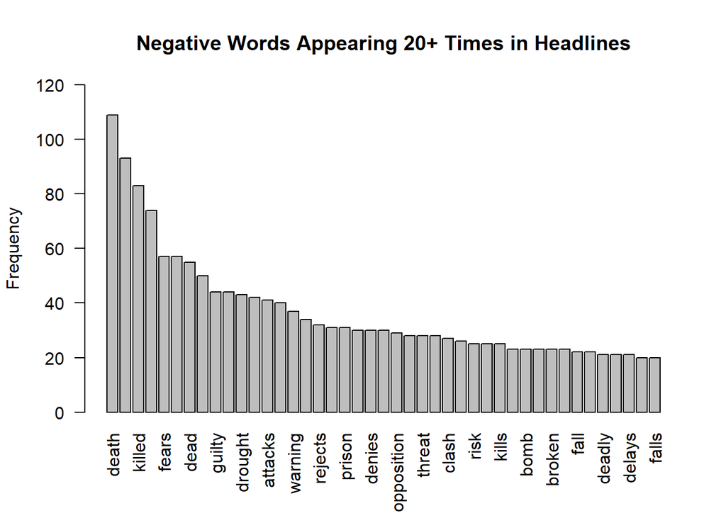

```r
barplot(sort(neg_match[neg_match>=20], decreasing=TRUE), ylab="Frequency", las=2, ylim=c(0,120), main="Negative Words Appearing 20+ Times in Headlines")
```

The percentage of positive words in news headlines is 18.5%, and the percentage of negative words is 38.5%.

Let’s get the number of articles published in each year and month. Note that the chunk below creates two new variables `count` and `yearmonth`:

```r
news <- news %>% group_by(year,month) %>% mutate(count=n(), yearmonth = paste(year, month,sep = '/')) %>% arrange(year,month,day)
```

# Question 9

Using `ggplot2`, create a barplot for the frequency of articles released in each year and month. On the x axis, you should have year month, e.g., 2003/10, 2003/11, 2003/12, 2004/1, on the y-axis you should have the number of articles released in the data. Do you see a change in the number of articles released across years? (Hint: use `factor()` with `levels=` options specified when you call `aes(x=)` to have a proper chronological sorting on your x axis. Use `+theme(axis.text=element_text(size=4,angle=90)` to fit the dates on the x axis.)

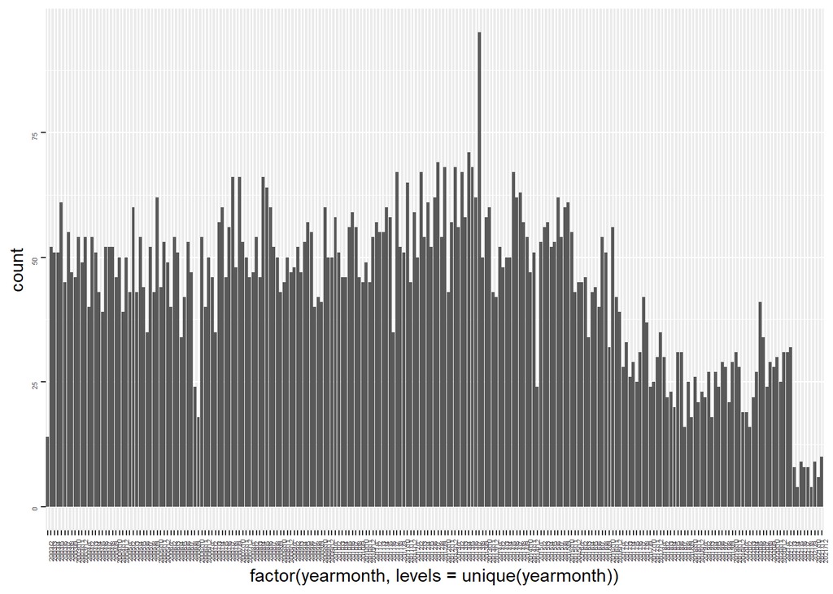

```r
ggplot(news, aes(x=factor(yearmonth, levels = unique(yearmonth)))) + geom_bar() + theme(axis.text=element_text(size=4,angle=90))
```

```r
newCharVector <- news$headline_text

# news$yearmonth
# head(news)

# aggregate(news, by=list(yearmonth=news$yearmonth), FUN=sum)
# ggplot(news, aes(x=news$yearmonth, y=news[])) + geom_bar()
# Old code for reference
```

The number of articles released across years is decreasing on average. The only notable exception is the maximum count, which we see in the middle of the barplot to be much greater than all the frequency data around it.

Let’s now practice working with `quanteda` and `corpus` packages. Install the packages first if you don’t have them in your computer and load them in in R.

```r
library("quanteda")
# library("corpus") # no longer available
```

# Question 10

Using the `term_stats()` function, return the 20 most frequent single words that show up in the data. Make sure to filter out * punctuation * symbols * stopwords

[output not shown]